# PS Final Research Project

Roman Mutel, Taras Yaroshko

# Introduction

Since the coffee was brought to Europe, it became the most popular morning drink and formed a huge amount of different cultures around growing, roasting, brewing and consuming coffee beans. Back in the days it replaced beer, fueling the industrialization! And now it provides us an interesting idea for a research project for probability and statistics course!

## Tested Hypothesis

The aim of this work is to test if the coffee consumption per capita is **normally distributed**. Also, we will see, if Europeans **consume more coffee** than Americans. Another interesting question is how strong is the relation between the amount of imported coffee beans and reexported (roasted and packed) coffee. Is the imported amount relies more on the consumers, or on the roasters?

## Notes on the Data

The research is based on [International Coffee Organization](https://www.ico.org/new_historical.asp?section=Statistics) data, which brings us the data about coffee production, trade, consumption, etc. of ICO member countries from 1990 up to 2019. We will analyze only the 2019 year statistics, since it is the last possible year, and also the trade was not affected by COVID-19 before 2020.

Another important data source is [World Development Indicators](https://data.worldbank.org/indicator/SP.POP.TOTL), which provides the data about countries population. Since we would like **identical** random variables, using absolute values **is not correct**, so we have to preprocess the data and transform it from *coffee-bags-per-country* into *kilograms-per-capita*. The data is preprocessed using the Python script one can find in the Github repository.

Another important moment – Luxembourg statistic is abnormally large due to the size of the country and the high percentage of urban citizens. Therefore we decided to exclude it from our analysis to have no anomalies. Sorry, Luxembourg.

# Data Overview

Our dataset contains data about 32 countries which import, consume and reexport coffee. The values are in kilogram per capita Let us see main statistics of the dataframe and visualize it!

```r
coffee_data <- read.csv(file="datasets/Coffee_Dataset_2019.csv")
coffee_data
```

```
##           country imports reexports consumption
## 1         Austria  9.7806    1.8525      7.9281
## 2         Belgium 32.3731   26.1826      6.1905
## 3        Bulgaria  6.7511    3.1122      3.6389
## 4     Switzerland 22.5885   14.7903      7.5069
## 5          Cyprus  6.5049    1.1357      5.6358
## 6         Czechia  9.0458    4.3079      4.7379
## 7         Germany 16.1977    9.9655      6.2605
## 8         Denmark  9.3691    1.3394      8.0298
## 9           Spain  7.6167    3.5335      4.1408
## 10        Estonia  6.6855    1.1458      5.5397
## 11        Finland 16.4678    1.8207     14.6471
## 12         France  7.1166    1.6133      5.5135
## 13 United Kingdom  4.9862    1.5980      3.3842
## 14         Greece  6.9744    0.5977      6.3767
```

[output cut: 18 more lines]

```r
summary(coffee_data)
```

```
##    country             imports         reexports        consumption
##  Length:32          Min.   : 2.531   Min.   : 0.0007   Min.   : 2.497
##  Class :character   1st Qu.: 6.288   1st Qu.: 1.0608   1st Qu.: 3.624
##  Mode  :character   Median : 7.241   Median : 1.8366   Median : 5.463
##                     Mean   : 9.618   Mean   : 4.0588   Mean   : 5.553
##                     3rd Qu.:10.369   3rd Qu.: 4.4237   3rd Qu.: 6.290
##                     Max.   :32.373   Max.   :26.1826   Max.   :14.647
```

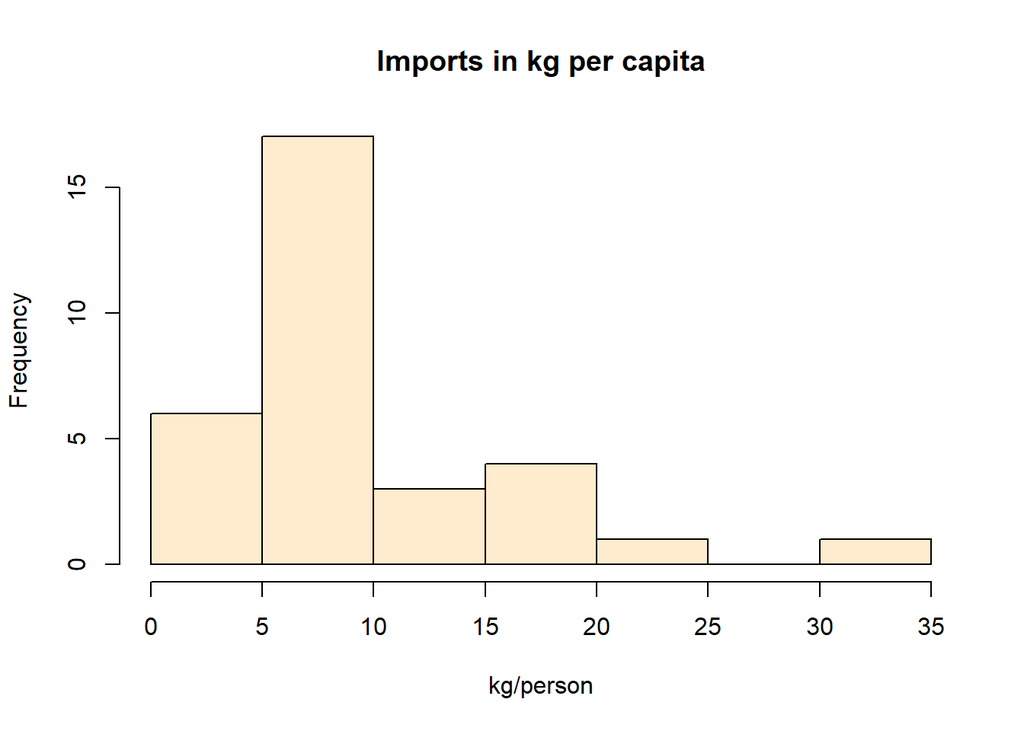

```r
hist(coffee_data$imports,
     col = "blanchedalmond",
     main = "Imports in kg per capita",
     xlab = "kg/person"
)
```

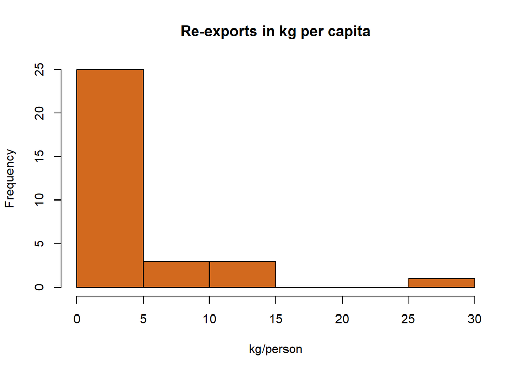

```r
hist(coffee_data$reexports,
     col = "chocolate",
     main = "Re-exports in kg per capita",
     xlab = "kg/person"
)
```

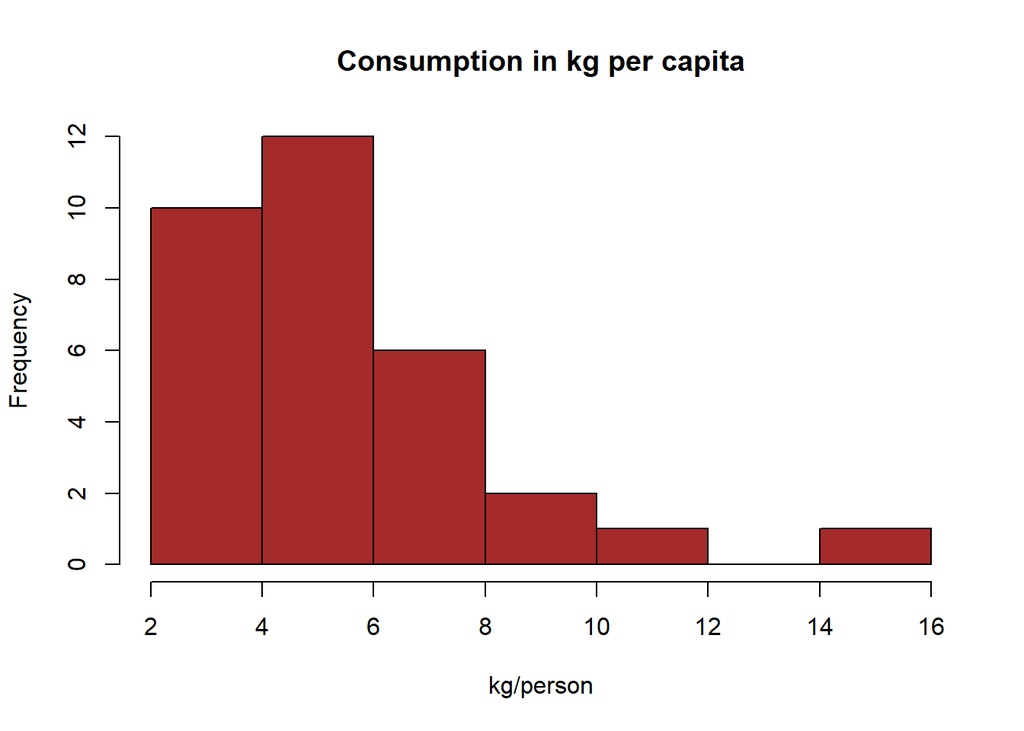

```r
hist(coffee_data$consumption,
     col = "brown",
     main = "Consumption in kg per capita",
     xlab = "kg/person"
)
```

From the first look, we can conclude that most of the countries reexport quite small amount of coffee. This might happen because of the the traditions and/or because of the location of the big ports (Belgium, Netherlands, Germany, and, unexpectedly, Slovenia and Switzerland are among the leaders)

Imports and consumption values are more “normally” distributed and there seems to be less anomalies. Let us proceed with the first test!

# Testing the Normality

As was mentioned, imports and consumption seem more “normally” distributed at the first look (even though Finland is far ahead of the other countries, most probably because of the small daytime length). But we should not be fooled and trust the numbers! To acquire the numbers, let us perform a **Kolmogorov goodness-of-fit test!**

Kolmogorov test for the **imports**:

```r
mu <- mean(coffee_data$imports)
sigma <- sd(coffee_data$imports)
ks.test(coffee_data$imports, "pnorm", mu, sigma)
```

```
##
##  Exact one-sample Kolmogorov-Smirnov test
##
## data:  coffee_data$imports
## D = 0.21548, p-value = 0.08768
## alternative hypothesis: two-sided
```

Kolmogorov test on normality of the imports gives us **p-value of 0.088**, which is small, but not enough ( (>0.05) to reject the null hypothesis, which states that the data is normally distributed. We cannot surely reject the hypothesis that the data is normally distributed, but since the p-value is relatively small, it would not be wise to say that the data is perfectly normal.

```r
mu <- mean(coffee_data$consumption)
sigma <- sd(coffee_data$consumption)
ks.test(coffee_data$consumption, "pnorm", mu, sigma)
```

```
##
##  Exact one-sample Kolmogorov-Smirnov test
##
## data:  coffee_data$consumption
## D = 0.15316, p-value = 0.4003
## alternative hypothesis: two-sided
```

Unlike the case with the imports, KS test on the consumption data results in **p-value of 0.4**, which is a large p-value. Thus, we cannot reject the hypothesis which suggested the data to be normally distributed. We should take into account, that the sample is of medium size (32 random variables), thus Kolmogorov test can be **inaccurate**, yet it still has meaning and shows us, that **consumption of coffee is normally distributed** among selected countries.

# Testing the equality of means

An interesting question is who drinks more coffee on average: Europeans or Americans? We all know that every American starts their day with a fresh cup of coffee, but, at the same time, there are lots of European countries that are famous for their delicious cappuccino or espresso. So, who is the winner here?

To determine it, we will use the **t-test**, which is applicable when we want to check the equality of means (and the variance of samples is unknown).

Constructing the null-hypothesis and the alternative hypothesis: $H_0: \mu = \mu_0$ vs. $H_1: \mu > \mu_0$. For the one-sided alternative $H_1$ we are going to use $C_{\alpha} = \{x \in \mathbb{R}^n | t(x) \geq t_{1-\alpha}^{(n-1)}\}$.

```r
us_mean <- coffee_data$consumption[32] # index of United States row
european_data <- coffee_data$consumption[0:31]
t.test(european_data, mu=us_mean, alternative = "greater")
```

```
##
##  One Sample t-test
##
## data:  european_data
## t = 1.2606, df = 30, p-value = 0.1086
## alternative hypothesis: true mean is greater than 4.9907
## 95 percent confidence interval:
##  4.789822      Inf
## sample estimates:
## mean of x
##  5.570665
```

## Summary

What does this tell us? Well, the **p-value** that we got is 0.1086, therefore, we fail to reject our null-hypothesis (which stated that the mean of coffee consumption in European countries is equal to the US consumption rate). That means that, although the daily life of those who consume coffee in Europe and US may be different, they drink pretty much the same amount of coffee per day.

# Testing the relation between import and re-export

Who is more responsible for what happens with imported coffee: domestic consumers or roasters, which process and resell coffee beans?

Let’s start with defining our linear model:

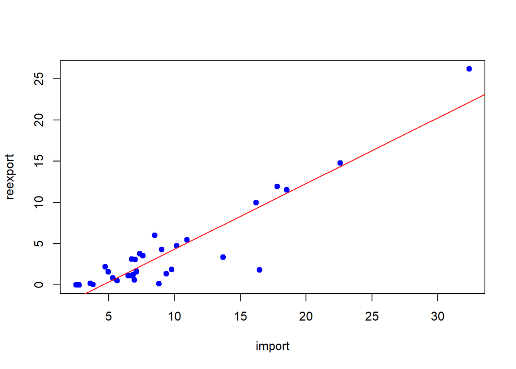

```r
import <- coffee_data$imports
reexport <- coffee_data$reexports
import_reexport_lm <- lm(reexport~import)
plot(import, reexport, pch=19, col="blue")
abline(import_reexport_lm, col = "red")
```

```r
print(summary(import_reexport_lm))
```

```
##
## Call:
## lm(formula = reexport ~ import)
##
## Residuals:
##     Min      1Q  Median      3Q     Max
## -7.6896 -0.4855  0.3812  1.2533  4.0132
##
## Coefficients:
##             Estimate Std. Error t value Pr(>|t|)
## (Intercept) -3.59648    0.71236  -5.049 2.03e-05 ***
## import       0.79590    0.06204  12.830 1.03e-13 ***
## ---
## Signif. codes:  0 '***' 0.001 '**' 0.01 '*' 0.05 '.' 0.1 ' ' 1
##
## Residual standard error: 2.201 on 30 degrees of freedom
## Multiple R-squared:  0.8458, Adjusted R-squared:  0.8407
## F-statistic: 164.6 on 1 and 30 DF,  p-value: 1.031e-13
```

```r
cat("Correlation coefficient between re-export and import is: ", cor(reexport, import))
```

```
## Correlation coefficient between re-export and import is:  0.9196934
```

As we see, the correlation coefficient between re-export and import is really high (0.9196934). As we know, a correlation of -1.0 indicates a perfect negative correlation, and a correlation of 1.0 indicates a perfect positive correlation. Therefore, we can conclude that there is a surprisingly high relationship between those two processes. For instance, when the amount of import increases, the amount of re-export increases, too. We can say that when import moves higher (or lower), re-export moves in the same direction with *almost* the same magnitude.

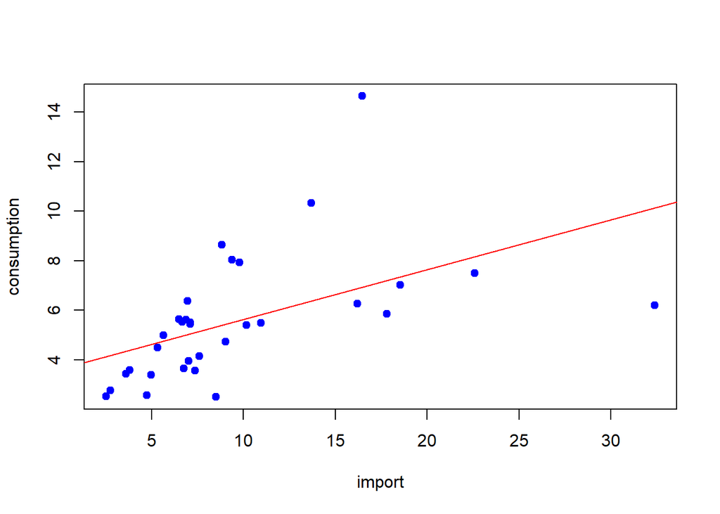

```r
consumption <- coffee_data$consumption
consumption_reexport_lm <- lm(consumption~import)
plot(import, consumption, pch=19, col="blue")
abline(consumption_reexport_lm, col = "red")
```

```r
print(summary(consumption_reexport_lm))
```

```
##
## Call:
## lm(formula = consumption ~ import)
##
## Residuals:
##     Min      1Q  Median      3Q     Max
## -3.9496 -1.2597 -0.4741  0.5875  7.7137
##
## Coefficients:
##             Estimate Std. Error t value Pr(>|t|)
## (Intercept)  3.61341    0.71392   5.061 1.96e-05 ***
## import       0.20161    0.06217   3.243   0.0029 **
## ---
## Signif. codes:  0 '***' 0.001 '**' 0.01 '*' 0.05 '.' 0.1 ' ' 1
##
## Residual standard error: 2.206 on 30 degrees of freedom
## Multiple R-squared:  0.2595, Adjusted R-squared:  0.2349
## F-statistic: 10.52 on 1 and 30 DF,  p-value: 0.0029
```

```r
cat("Correlation coefficient between consumption and import is: ", cor(consumption, import))
```

```
## Correlation coefficient between consumption and import is:  0.5094485
```

## Summary

On the other hand, the correlation coefficient for consumption and import is a little bit higher than **0.5**. So, one can say that these processes are *moderately* *correlated*. This is an interesting observation, because we mostly associate more import with more consumption, however, coffee roasters have more influence on the import statistics.

Also, we have to remember that correlation does not imply causation – a lot of different other things (often called confounding variables) may be involved, and the more accurate explanation we want to get, the more variables we have to include in our calculations so that we can understand the data better.